# delivery time experiment

Yulong Gong, Tzuhua Huang, Chenzhi Pan, Muyan Xie, Yichi Zhang, Yangyang Zhou

# Introduction

The COVID-19 pandemic challenged our life in many aspects,but some industries grew quickly during this period, such as fresh delivery services. As many pieces of research have shown, in this fast-paced society, people value the speed of delivery service. According to Resendes (2020), 31% of customers use delivery service at least twice a week. 33% of customers are willing to pay money in exchange for fast delivery.

For this project, we would like to dive into the food delivery service industry. We’d like to take the standpoint of the third-party food delivery service platforms, such as Uber Eats, Chowbus, DoorDash, etc., which connect the restaurants and consumers. We want to analyze when everything holds constant, how the food delivery time interval will affect consumer’s willingness to place an order.

We wish our results could help us have a better understanding of the influence of wait time on whether a consumer would choose a service or not, which could be helpful in our career. Also, we wish our result to develop a win-win relationship between consumers and service platforms by helping platforms gain more profits and consumers have better user experience.

# Hypothesis and implications

We assume that the more precise the delivery time interval is, the more willingly a customer will place an order. In this case, the platform should improve the accuracy of estimated delivery time or optimize the delivery time to a narrower interval.

# Method

**Questionnaire Design** There are three steps for designing the questionnaire. Firstly, demographic information are collected. We would like to know if the participant is a student or an employee for an organization and if he/she is working/studying from home.

Second, we asked the participants’ experience of using food delivery service, as recommended by K.Foreit and J.Foreit(2004) in their paper. To be specific, the frequency of using food delivery services and whether the individual is an existing user for any existing platforms. We also collected the personal preference on food categories.

Next, we simulated two interfaces. For the treated group, the participant would see the ordering page with the delivery time interval of 10 minutes (e.g., Your food will be delivered between 7:00 pm -7:10 pm); while the control group will see the same restaurant as the treatment group. The only difference would be the delivery time interval is greater than 30 minutes (e.g., Your food will be delivered between 7:00 pm – 7:40 pm). We also provided the options across different food categories, and we chose the same image representation so we could eliminate the impact of food categories on participants’ decision-making as much as possible. In each question, the participant should decide if he/she would like to place an order based on the picture and the information we provided.

Finally, we asked the individual to provide the reasons if he/she chose unwilling to place an order in the previous questions. We would like to collect the potential reasons that might lead to participants’ decisions and examine if the results could support our hypothesis.

```r
# variable questions table
questions = data.table(
  Variables = c("'member'","'student'","'wfh'","'frequency'","'chinese'"),
  Question = c("Are you a member of any food delivery platforms?","Are you a student?","Do you currently work/study from home?","How often do you order delivery?","What's your favorite cuisine when you order takeout/delivery?")
)
kbl(questions)
```

| Variables | Question |
| --- | --- |
| ‘member’ | Are you a member of any food delivery platforms? |
| ‘student’ | Are you a student? |
| ‘wfh’ | Do you currently work/study from home? |
| ‘frequency’ | How often do you order delivery? |
| ‘chinese’ | What’s your favorite cuisine when you order takeout/delivery? |

**Participants**

To decide which participants would be in the treatment or control group, we decided to use the built-in function in Qualtrics, a survey design platform. By setting automatic randomization, the questionnaire would randomly present one of the interfaces to the individual with 50% chance seeing the treatment questions. By appropriately designing the randomizer in the questionnaire, we were able to randomize everyone into the control or treatment group in an attempt to avoid selection bias in the study.

To recruit the participants, we distributed our questionnaires in two ways. Firstly, we distributed it by posting messages in the ‘QuestromMSBA21’ Slack channel. Secondly, we also distributed through our social networking. Finally, we had a total of 91 respondents from under 19 to 39. Additionally, 54 identify as female, and 36 identify as male.

**Pre-Experiment Randomization/Balance Check**

```r
# work from home check
sample <- lm(wfh ~ any_treatment, data)
# student check
sample1 <- lm(student ~ any_treatment, data)
# membership check
sample2 <- lm(member ~ any_treatment, data)
# frequency check
sample3 <- lm(frequency ~ any_treatment, data)
# Chinese food check
sample4 <- lm(chinese ~ any_treatment, data)

# combine together
stargazer(sample, sample1, sample2, sample3, sample4, type = 'text')
```

```
##
## ===========================================================================
##                                            Dependent variable:
##                               ---------------------------------------------
##                                 wfh    student   member  frequency chinese
##                                 (1)      (2)      (3)       (4)      (5)
## ---------------------------------------------------------------------------
## any_treatment                  0.044    -0.067   0.156     0.111    0.044
##                               (0.067)  (0.057)  (0.098)   (0.101)  (0.097)
##
## Constant                      0.867*** 0.956*** 0.600*** 0.600***  0.689***
##                               (0.047)  (0.040)  (0.069)   (0.071)  (0.068)
##
## ---------------------------------------------------------------------------
## Observations                     90       90       90       90        90
## R2                             0.005    0.015    0.028     0.014    0.002
## Adjusted R2                    -0.006   0.004    0.017     0.002    -0.009
## Residual Std. Error (df = 88)  0.317    0.269    0.466     0.477    0.458
## F Statistic (df = 1; 88)       0.442    1.380    2.510     1.220    0.212
## ===========================================================================
## Note:                                           *p<0.1; **p<0.05; ***p<0.01
```

**EDA** From the below graph we notice that the majority of our participants ordered Chinese food.

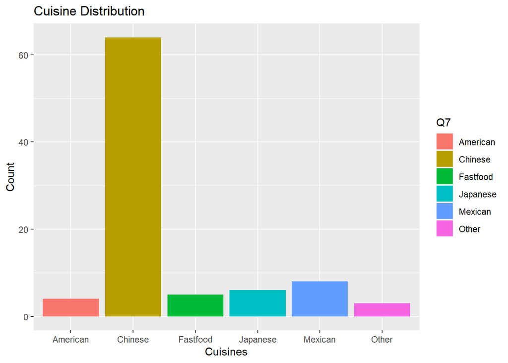

```r
#Cuisine distribution
cuisine <- ggplot(data = data,aes(x=Q7,fill=Q7))+
  geom_histogram(stat = 'count')+
  ggtitle('Cuisine Distribution')+
  ylab('Count') + xlab('Cuisines')
cuisine
```

From the order frequency chart we find out that most of our participants order food from delivery apps more than 2 times a week.

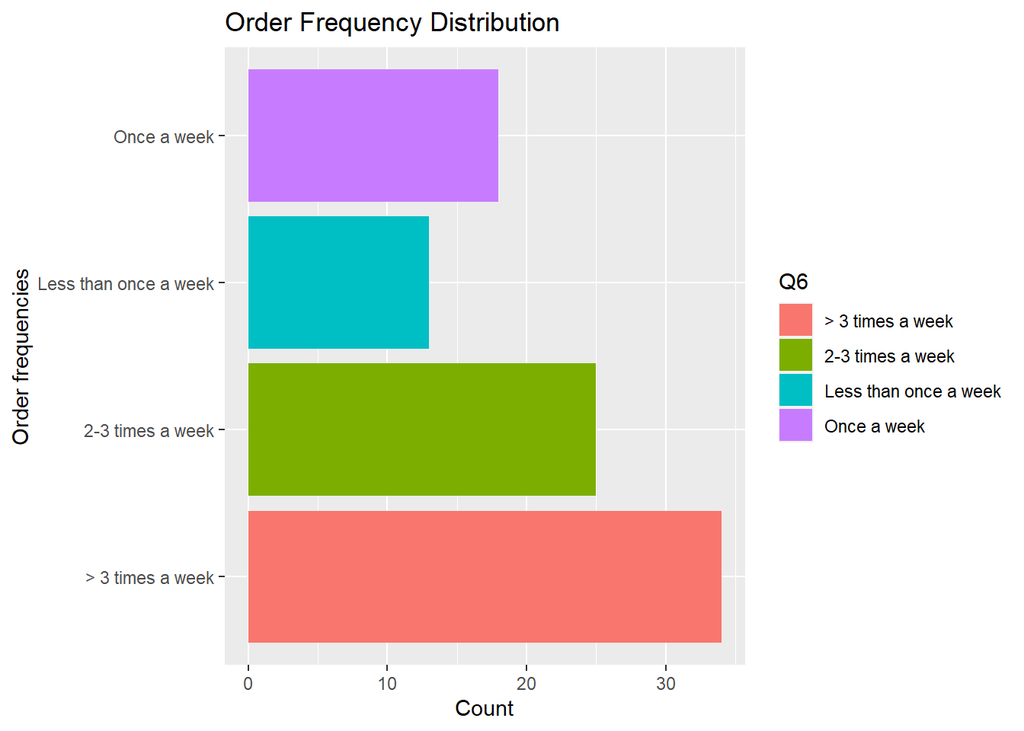

```r
#Order frequency
order <- ggplot(data = data,aes(x=Q6,fill=Q6))+
  geom_histogram(stat = 'count')+
  ggtitle('Order Frequency Distribution')+
  ylab('Count') + xlab('Order frequencies') + coord_flip()
order
```

```r
head(data)
```

[output not shown]

[output cut: 27 more lines]

# Data Analysis

We would like to perform a series of regressions to analyze the results of our experiment. First of all, we calculated average treatment effect for our experiment which is whether the range of delivery time provided affect the probability of ordering. Since our experiment included different types of cuisine trying to minimize differences on personal flavors, we compute the average or the probability that they will order food from five pictures we provided. Based on the result below, we observe that, in general, participants in treatment group are 13% more likely to order delivery than those in control groups. This result suggests that users are more likely to order food with small range of delivery time. In addition, below table suggests our result is statistically significant at 95% confidence level.

```r
reg1 <- feols(avg_score ~ any_treatment, data = data,se="white")
etable(reg1)
```

```
##                               reg1
## Dependent Var.:          avg_score
##
## (Intercept)     0.5733*** (0.0465)
## any_treatment     0.1333* (0.0600)
## _______________ __________________
## S.E. type       Heteroskedas.-rob.
## Observations                    90
## R2                         0.05308
## Adj. R2                    0.04232
```

Then, we added those variables from balance check as controls. However, they did not reduce variance in estimation.

```r
reg2 <- feols(avg_score ~ any_treatment + wfh + student + member, data = data, se='white')
etable(reg2)
```

```
##                               reg2
## Dependent Var.:          avg_score
##
## (Intercept)     0.5936*** (0.0745)
## any_treatment     0.1154. (0.0613)
## wfh                0.1075 (0.1367)
## student           -0.1353 (0.1064)
## member             0.0265 (0.0658)
## _______________ __________________
## S.E. type       Heteroskedas.-rob.
## Observations                    90
## R2                         0.06722
## Adj. R2                    0.02332
```

```r
#For all surveys
# reg3 <- feols(Japanese ~ any_treatment, data = data, se='white')
# reg4 <- feols(American ~ any_treatment, data = data, se='white')
# reg5 <- feols(Fast ~ any_treatment, data = data, se='white')
# reg6 <- feols(Chinese ~ any_treatment, data = data, se='white')
# reg7 <- feols(Italian ~ any_treatment, data = data, se='white')
# etable(reg3, reg4, reg5, reg6, reg7)
```

# Chinese vs non-Chinese

From the summary below we could observe that , there is a small differences on probability of ordering deliver services between users who favor Chinese and not. In addition, users who favor ordering Chinese cuisine are slight more in favor of short delivery time interval estimate.

```r
reg8 <- feols(avg_score~any_treatment*chinese,data,se='white')
etable(reg1,reg8)
```

```
##                                       reg1               reg8
## Dependent Var.:                  avg_score          avg_score
##
## (Intercept)             0.5733*** (0.0465) 0.4714*** (0.0762)
## any_treatment             0.1333* (0.0600)    0.1119 (0.1117)
## chinese                                       0.1479 (0.0952)
## any_treatment x chinese                       0.0203 (0.1317)
## _______________________ __________________ __________________
## S.E. type               Heteroskedas.-rob. Heteroskedas.-rob.
## Observations                            90                 90
## R2                                 0.05308            0.11411
## Adj. R2                            0.04232            0.08321
```

```r
cate_chinese_1 <- mean(data[chinese == 1& any_treatment == 1, avg_score])-mean(data[chinese == 1& any_treatment == 0, avg_score])
cate_chinese_0 <- mean(data[chinese == 0& any_treatment == 1, avg_score])-mean(data[chinese == 0& any_treatment == 0, avg_score])
cat(cate_chinese_1,cate_chinese_0)
```

```
## 0.132 0.112
```